# Bakersfield Cactus Sampling Analysis

Malory Owen, Brooke Wainwright, Chris Lortie

1/31/2019

#### Let’s explore the abundance, size, and health of the federally and state endangered cactus, *Opuntia basilaris* var. *treleasei*, also known as the Bakersfield Cactus. A historical population exists at Wind Wolves Reserve, and after a particularly rainy season threatened to kill the historical population, others populations were establish with propagated paddles from the historical population.

## Data

#### Before we get into it, let’s just explore the data a bit.

```r
head(baca) #display it
```

```
## # A tibble: 6 x 15
##   Protection   Tag Health Secondary Tertiary Quaternary Length.cm Width.cm
##   <chr>      <dbl>  <dbl>     <dbl>    <dbl>      <dbl>     <dbl>    <dbl>
## 1 Rebar         18      5        NA       NA         NA        NA       NA
## 2 Rebar         25      4        NA       NA         NA        NA       NA
## 3 Rebar         31      5        NA       NA         NA        NA       NA
## 4 Rebar         32      4        NA       NA         NA        NA       NA
## 5 Rebar         34      4        NA       NA         NA        NA       NA
## 6 Rebar         64      5        NA       NA         NA        NA       NA
## # ... with 7 more variables: Area.cm2 <dbl>, Year <chr>, Notes <chr>,
## #   Population <chr>, Monitor <dbl>, x <dbl>, y <dbl>
```

```r
#How many cacti per site?
count(baca, Population)
```

```
## # A tibble: 5 x 2
##   Population      n
##   <chr>       <int>
## 1 Historic      141
## 2 Lobos         124
## 3 Muddy         135
## 4 Salt           86
## 5 San Emigdio   108
```

```r
#Do we have different numbers of cacti measured each year?
count(baca, Year)
```

```
## # A tibble: 5 x 2
##   Year          n
##   <chr>     <int>
## 1 2012-2013   146
## 2 2013-2014    89
## 3 2014-2015    95
## 4 2015-2016   122
## 5 2016-2017   142
```

```r
#How many cacti per protection type?
count(baca, Protection)
```

```
## # A tibble: 3 x 2
##   Protection     n
##   <chr>      <int>
## 1 Rebar        292
## 2 Rocks        251
## 3 Vaca          51
```

## Location: Where are the cacti?

```r
#map all points
baca_map <- leaflet() %>%
  addTiles() %>%
  addCircleMarkers(lng = baca$x, lat = baca$y, radius = 5, color = "#DEAFD6")

baca_map #print
```

[interactive chart not shown]

```r
#Map the years
pal2 <- colorFactor(c("#366286", "#29266d", "#95b2d5", "#95d5c9", "#a2cd83"), domain = c("2012-2013", "2013-2014", "2014-2015", "2015-2016", "2016-2017"))

leaflet(baca) %>% addTiles() %>%
  addCircleMarkers(
    lng = baca$x, lat= baca$y,
    color = ~pal2(Year),
    stroke = FALSE, fillOpacity = 0.5
  ) %>%
   addLegend("bottomright", pal = pal2, values = ~Year,
    title = "Cactus Year",
    opacity = 1
  )
```

[interactive chart not shown]

```r
#Map the protecters
pal <- colorFactor(c("#6d4a5c", "#f2c29a", "#a2cd83"), domain = c("Rebar", "Rock", "Vaca"))

leaflet(baca) %>% addTiles() %>%
  addCircleMarkers(
    lng = baca$x, lat= baca$y,
    color = ~pal(Protection),
    stroke = FALSE, fillOpacity = 0.5
  ) %>%
   addLegend("bottomright", pal = pal, values = ~Protection,
    title = "Protection Type",
    opacity = 1
  )
```

[interactive chart not shown]

```r
#Map the health
pal3 <- colorFactor(c("black", "sienna", "indianred", "orange", "khaki", "#859469"), domain = c("0", "1", "2", "3", "4", "5"))

leaflet(baca) %>% addTiles() %>%
  addCircleMarkers(
    lng = baca$x, lat= baca$y,
    color = ~pal3(Health),
    stroke = FALSE, fillOpacity = 0.5
  ) %>%
   addLegend("bottomright", pal = pal3, values = ~Health,
    title = "Health of Cacti",
    opacity = 1
  )
```

[interactive chart not shown]

####Zoom in for a closer look on HTML Version.

```r
#![Map of all cactus points.](Map_Images/All.png)
#![Map of cacti measured each year.](Map_Images/Year.png)
#![Map of protection types for each cactus.](Map_Images/Protection.png)
#![Map of the health index for each cactus.](Map_Images/Health.png)
```

## Size of Cacti

#### We’ve seen the spatial distribution of our cacti by several different factors, but now let’s take a look at how they measure up. For pollinators, there is evidence that height of an infloresence impacts pollinator visition, and the same may be true for avian frugivores. For this data, we do not have a height measurement, but we do have area. Understanding how size varies across the population may illuminate some truths about bird-cactus double mutualism.

#### Size may also illuminate the age, reproductive succes, or health of the cacti, especially for those propagated from the historical population.

```r
nabaca <- baca %>% drop_na(Area.cm2)


mean(nabaca$Area.cm2) #mean area for all
```

```
## [1] 1216.241
```

```r
tapply(nabaca$Area.cm2, nabaca$Population, mean) #mean height of each population
```

```
##    Historic       Lobos       Muddy        Salt San Emigdio
##    889.9787   1137.9524    907.5918   1406.5263   1818.8636
```

```r
tapply(nabaca$Area.cm2, nabaca$Protection, mean) #mean height of each protection method
```

```
##    Rebar    Rocks     Vaca
## 1342.981  953.033 1673.522
```

```r
tapply(nabaca$Area.cm2, nabaca$Year, mean) #mean height over each year--are they growing?
```

```
## 2012-2013 2013-2014 2014-2015 2015-2016 2016-2017
##  652.8750 2042.1778 1554.3261 1066.9412  627.6087
```

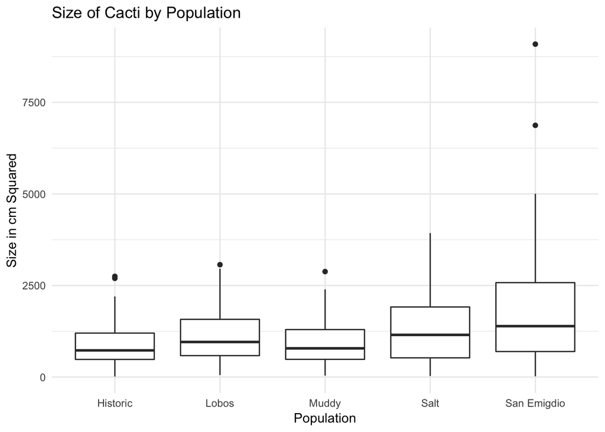

```r
ggplot(nabaca, aes(x = Population, y=Area.cm2)) +
  geom_boxplot() + labs(title = "Size of Cacti by Population", x = "Population", y = "Size in cm Squared") +
  theme_minimal()
```

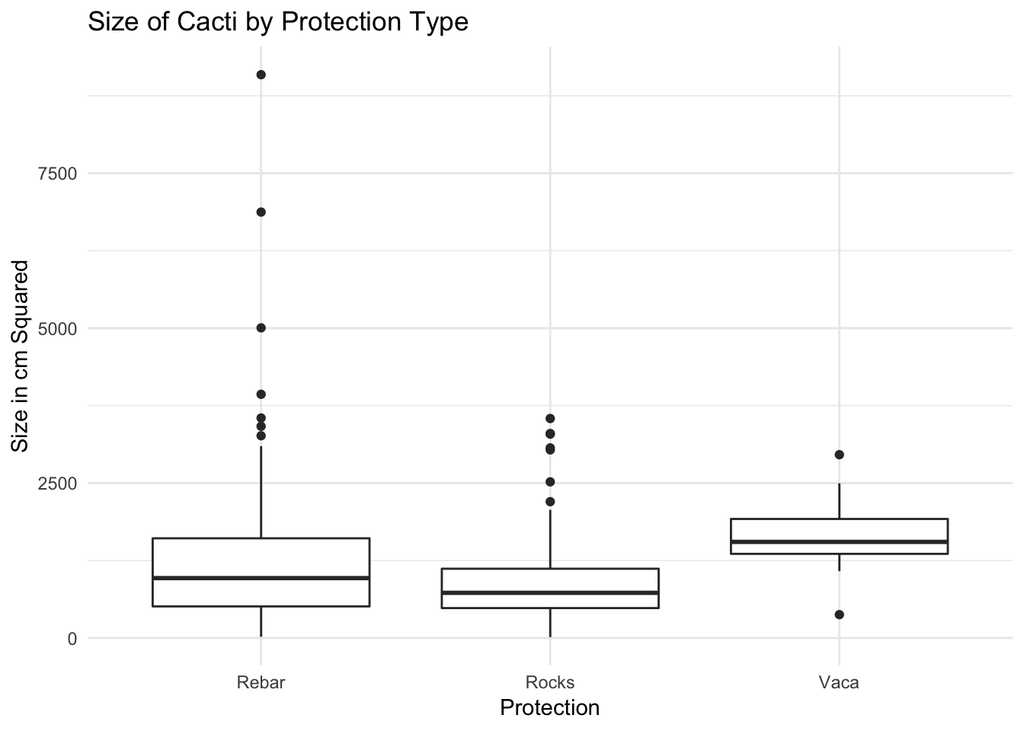

```r
ggplot(nabaca, aes(x = Protection, y=Area.cm2)) +
  geom_boxplot() + labs(title = "Size of Cacti by Protection Type", x = "Protection", y = "Size in cm Squared") +
  theme_minimal()
```

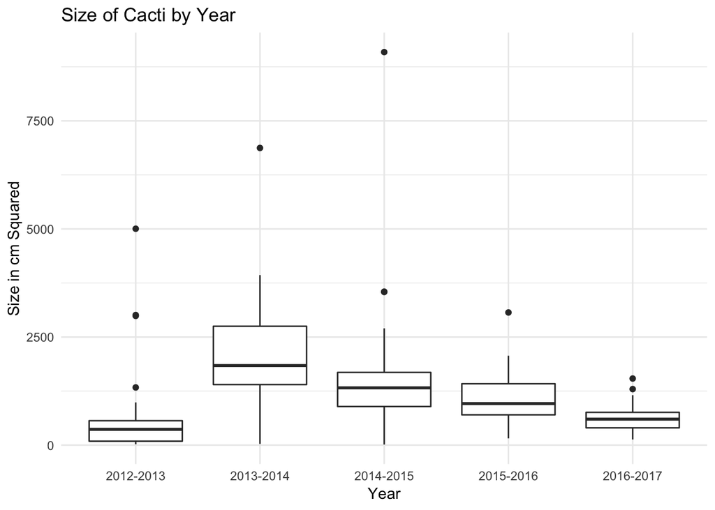

```r
ggplot(nabaca, aes(x = Year, y=Area.cm2)) +
  geom_boxplot() + labs(title = "Size of Cacti by Year", x = "Year", y = "Size in cm Squared") +
  theme_minimal()
```